# Contemporary Humans and the Environment

## Anthropogenic stressors contribute to change

- **Historical build-up:**
  - hunting and megafaunal extinctions
  - agriculture and domestication
  - urbanization and population growth
- **Current trends (today’s topic)**
  - land use change
  - pollution
  - globalization
- **Equivalent to a natural stressor if an organism’s response is similar or identical**

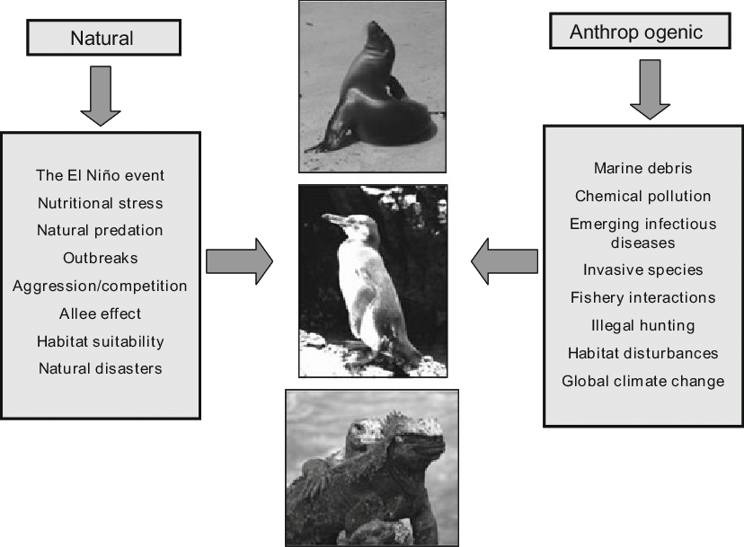

## Land-use change levels up

- **Before the Anthropocene, human induced land-use change was mostly regional**
  - hunting, agriculture and increased urbanization
  - Thus, habitat modification is not new

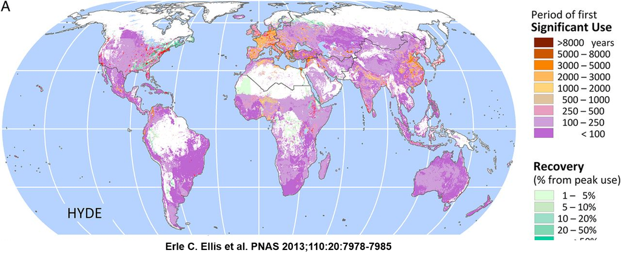

## How have humans modfied 75% of the land surface?

- **Agricultural intensity must match demand**
- **Freshwater is a limiting resource**
  - > 40% dedicated to agriculture
  - deep water sources are needed
  - water needs to be diverted
- **Minerals and metals are needed for everything**
- **Natural ecosystems provide raw materials**
  - and get it the way of urbanization

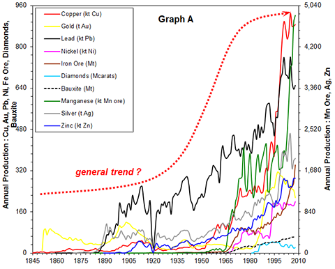

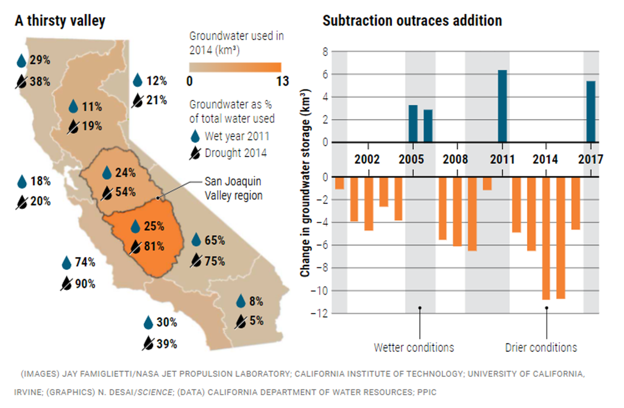

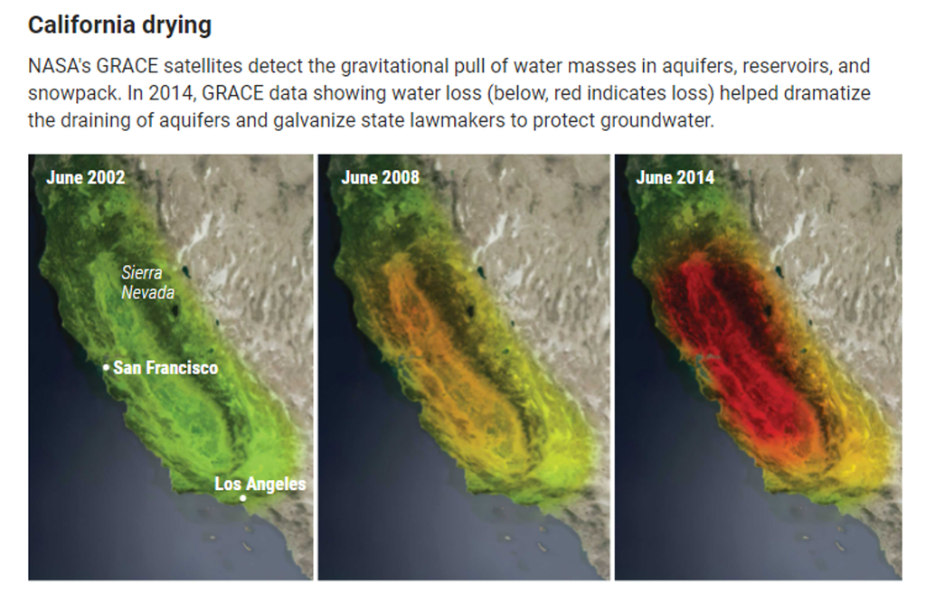

## Human activities create contaminants

- **From *point* sources to *diffuse* impacts**
  - California oil spill vs. fertilizer run-off in Chesapeake Bay

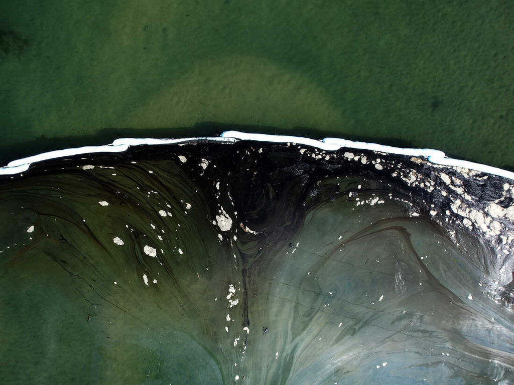

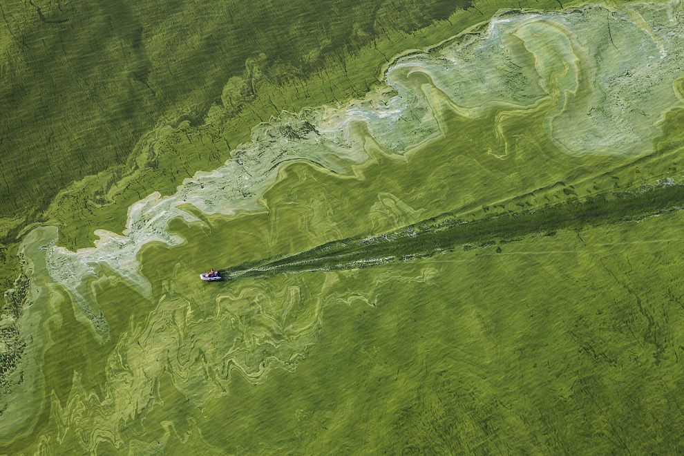

## Human activities create contaminants: Excess carbon dioxide

[figure not shown]

## Human activities create contaminants: Other greenhouse gases

[figure not shown]

[figure not shown]

## Humans are now connected worldwide

- **The impacts of *globalization* on natural systems is huge**
- **Humans move species around - for better or worse**
  - necessary for food systems
  - unintentional as part of trade (invasive species)
  - intentional with unknown consequences
- **Infrastructure of globalization also disrupts natural systems**
  - roads fragment landscapes
  - transportation pollutes
  - politics of trade divides wealth

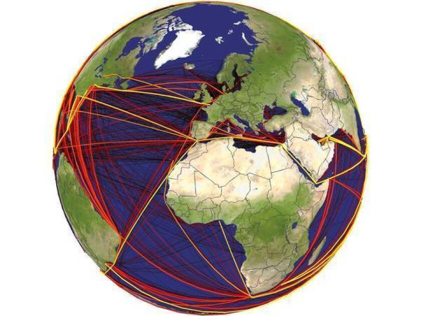

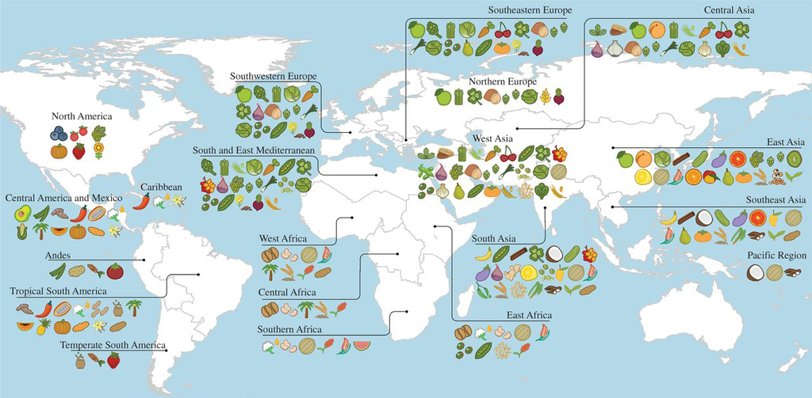

## How do stressors interact?

**Synergy: when the total effect is *more* than the sum of the individual effects**

**Partially additive: when the total effect is *less* than the sum of the individual effects**

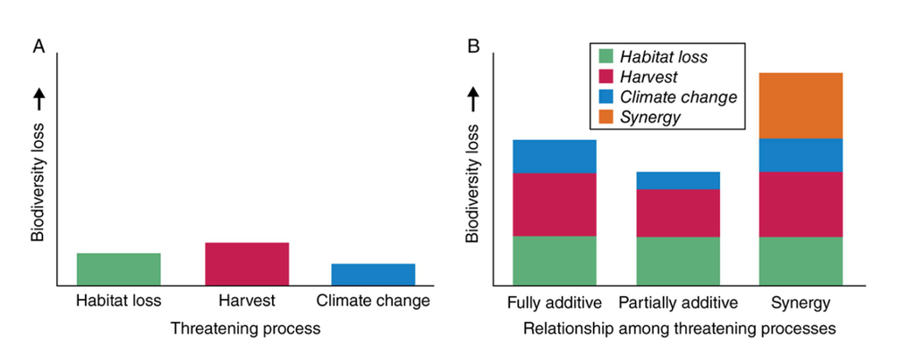

## Big picture: These stresses have altered Earth’s climate systems

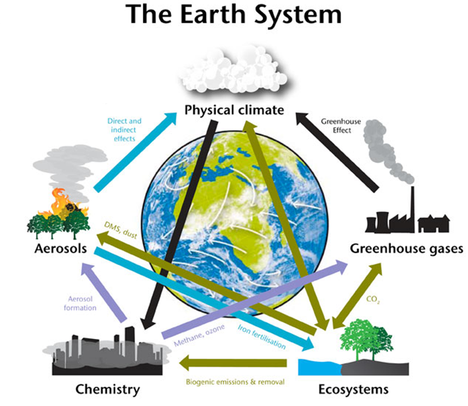

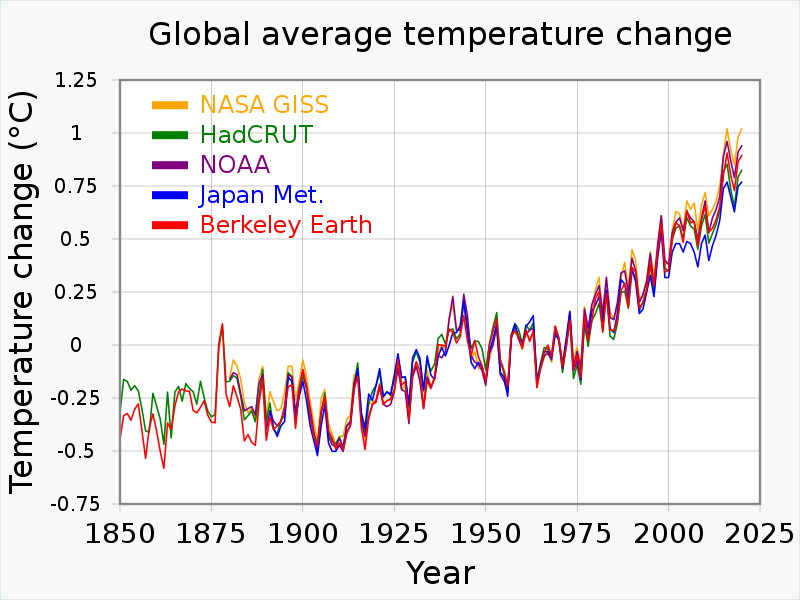

## The climate system is powered by solar radiation.

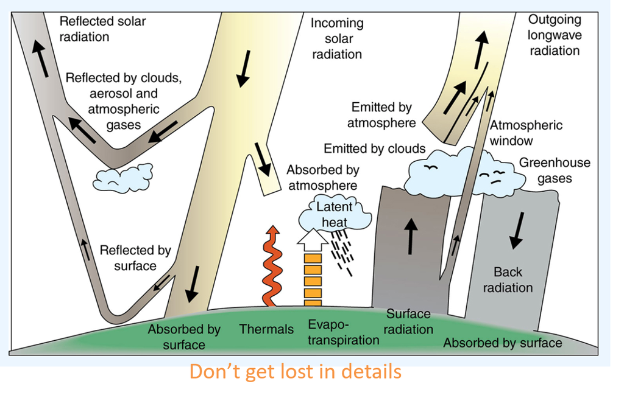

## Incoming solar radiation balanced by outgoing radiation

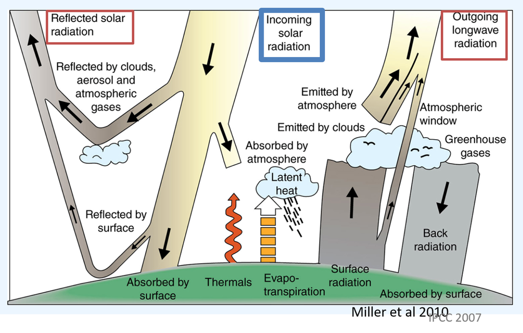

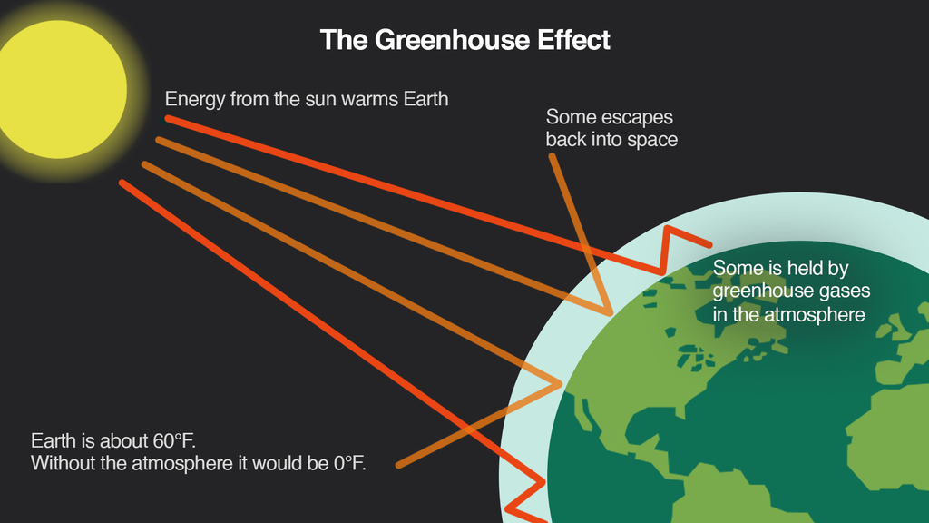

## If balance interupted, Earth warms or cools

**The radiative balance can be perturbed by “forcings’**

- **Each ‘forcing’ can alter:**
  - incoming solar radiation (shortwave)
  - solar radiation that is reflected
  - longwave radiation emitted from Earth
- **Forcings largely a function of greenhouse gases**
  - each absorb longwave radiation

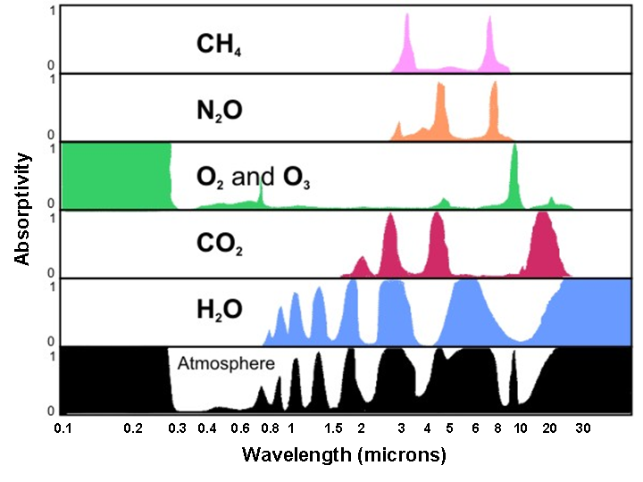

## Why does climate change over time?

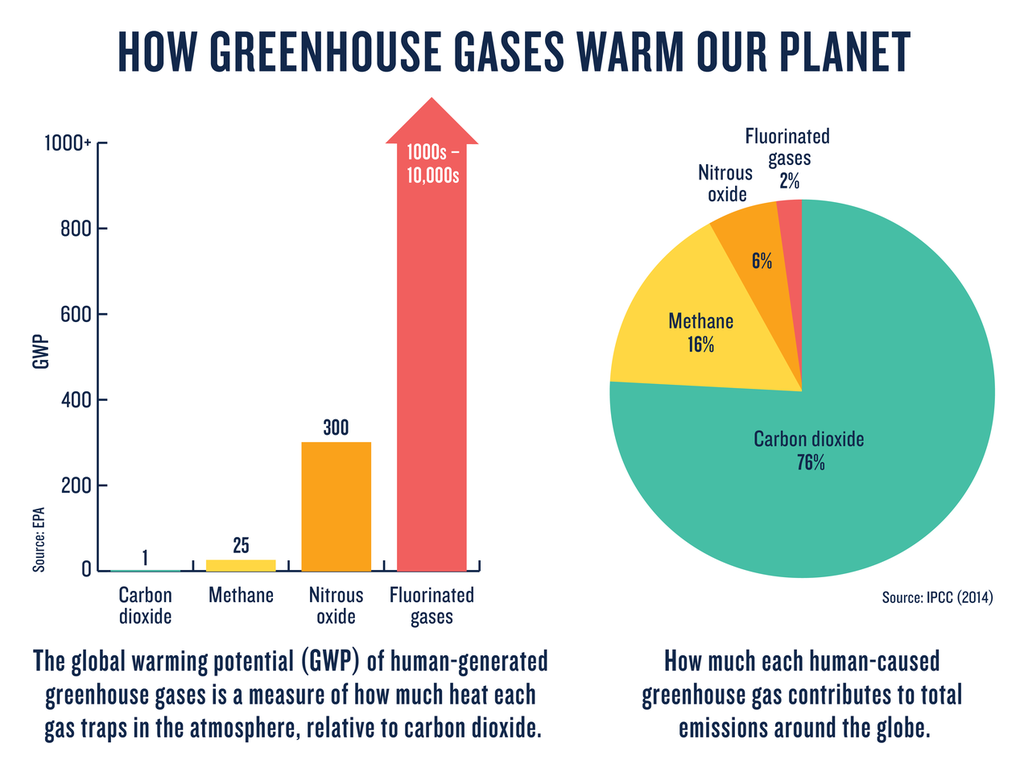

[figure not shown]

## Climate change is not new

[figure not shown]

## Climate change then versus now…

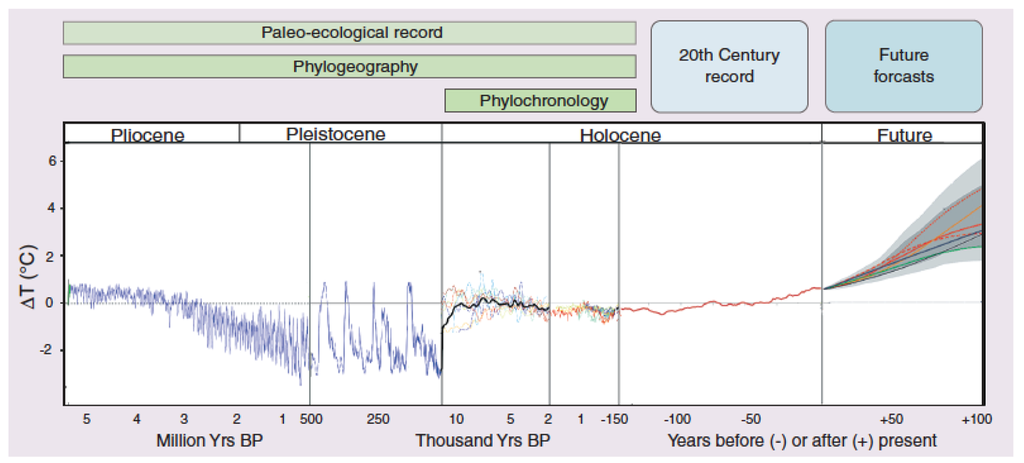

## Climate change then versus now…

**Contemporary climate change is different because of anthropogenic causes and velocity**  
**Same 5°C change >10x faster**

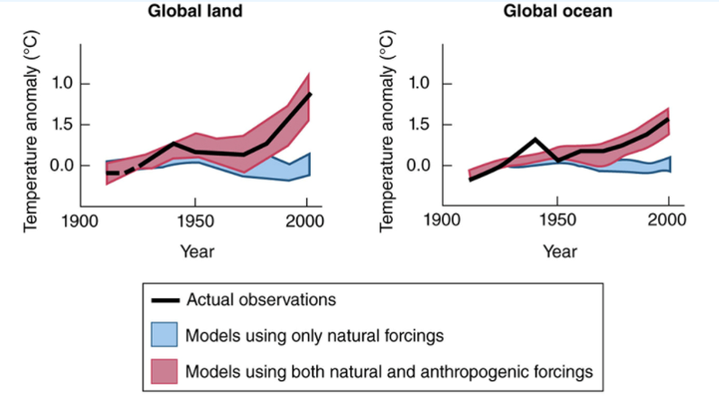

## We measure current change since Industrial age…

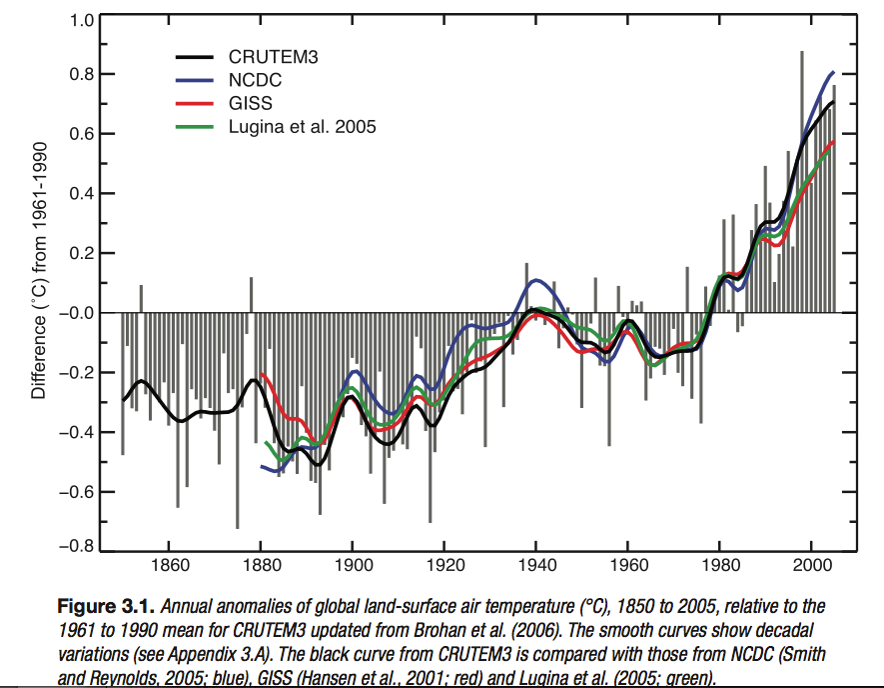

- **Global mean surface temperature has risen ~ 1 degree C over the last 100 years**
- **How much is left to come?**
  - depends on continued forcing
  - we can predict (based on trends)
  - always some uncertainty

## Future climate change is inevitable

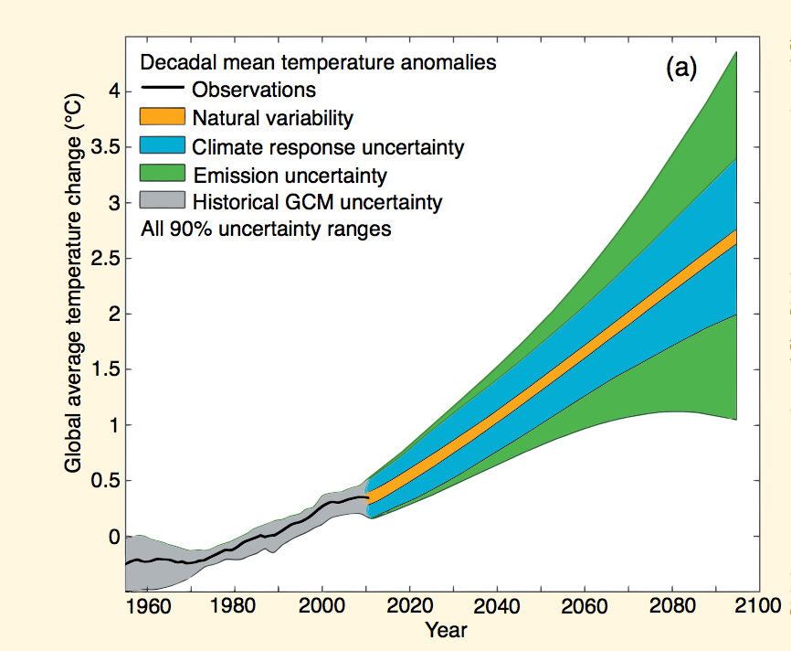

- **Global mean surface temperature has risen ~ 1 degree C over the last 100 years**
- **How much is left to come?**
  - depends on continued forcing
  - we can predict (based on trends)
  - always some uncertainty

## Temperature is just one part of Earth’s changing climate system

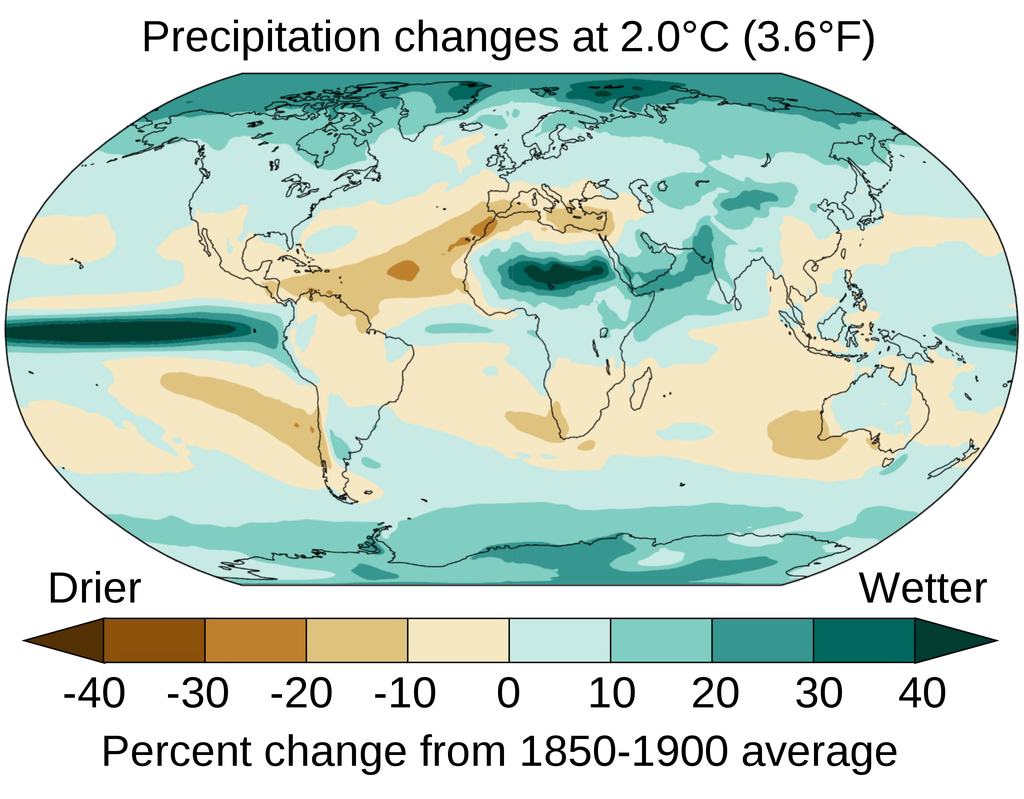

[figure not shown]

## Next up: Exam Time

[figure not shown]

[figure not shown]